# 2015 - 2018 MLB Pitch Data Exploration

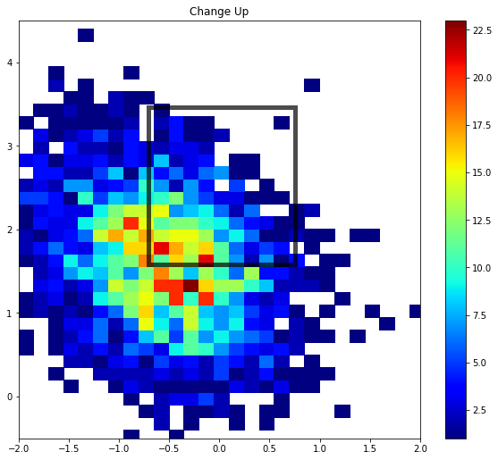

```python
left, width = 0.1, 0.65
bottom, height = 0.1, 0.65
bottom_h = left_h = left + width + 0.02

rect_scatter = [left, bottom, width, height]
#rect_histx = [left, bottom_h, width, 0.2]
#rect_histy = [left_h, bottom, 0.2, height]

plt.figure(1, figsize=(12, 10))

# start with a rectangular Figure


axScatter = plt.axes(rect_scatter)
#axHistx = plt.axes(rect_histx)
#axHisty = plt.axes(rect_histy)
bins_x = np.arange(-2, 0.1+2,0.15)
bins_y = np.arange(-1, 0.1+6, 0.15)
plt.hist2d(data = ch, x = 'px', y = 'pz', bins = [bins_x, bins_y], cmap = 'jet', cmin = 1);
axScatter.set_xlim((-2, 2))
axScatter.set_ylim((-0.5, 4.5))
someX = 0
someY = 3.4632659
axScatter.add_patch(Rectangle((someX - .7083 , someY - 1.8832 ), 1.467, 1.8832, color = 'black',fill=None, alpha=0.7, lw = 5))
plt.colorbar();
plt.title('Change Up');
```

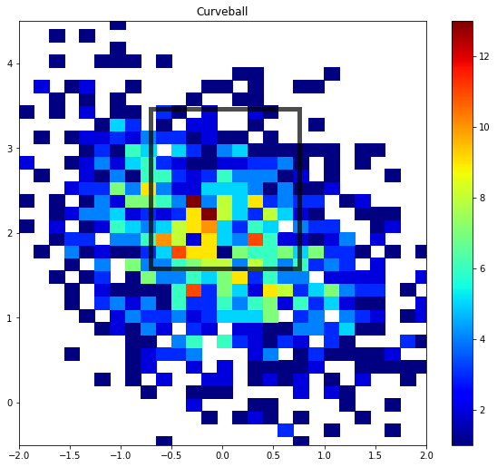

```python
left, width = 0.1, 0.65
bottom, height = 0.1, 0.65
bottom_h = left_h = left + width + 0.02

rect_scatter = [left, bottom, width, height]
#rect_histx = [left, bottom_h, width, 0.2]
#rect_histy = [left_h, bottom, 0.2, height]

plt.figure(1, figsize=(12, 10))

# start with a rectangular Figure


axScatter = plt.axes(rect_scatter)
#axHistx = plt.axes(rect_histx)
#axHisty = plt.axes(rect_histy)
bins_x = np.arange(-2, 0.1+2,0.15)
bins_y = np.arange(-1, 0.1+6, 0.15)
plt.hist2d(data = cu, x = 'px', y = 'pz', bins = [bins_x, bins_y], cmap = 'jet', cmin = 1);
axScatter.set_xlim((-2, 2))
axScatter.set_ylim((-0.5, 4.5))
someX = 0
someY = 3.4632659
axScatter.add_patch(Rectangle((someX - .7083 , someY - 1.8832 ), 1.467, 1.8832, color = 'black',fill=None, alpha=0.7, lw=5))
plt.colorbar();
plt.title('Curveball');
```

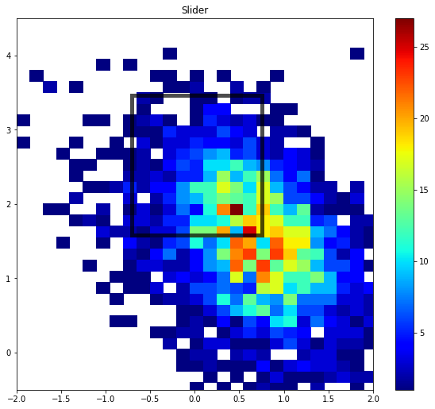

```python
left, width = 0.1, 0.65
bottom, height = 0.1, 0.65
bottom_h = left_h = left + width + 0.02

rect_scatter = [left, bottom, width, height]
#rect_histx = [left, bottom_h, width, 0.2]
#rect_histy = [left_h, bottom, 0.2, height]

plt.figure(1, figsize=(12, 10))

# start with a rectangular Figure


axScatter = plt.axes(rect_scatter)
#axHistx = plt.axes(rect_histx)
#axHisty = plt.axes(rect_histy)
bins_x = np.arange(-2, 0.1+2,0.15)
bins_y = np.arange(-1, 0.1+6, 0.15)
plt.hist2d(data = sl, x = 'px', y = 'pz', bins = [bins_x, bins_y], cmap = 'jet', cmin = 1);
axScatter.set_xlim((-2, 2))
axScatter.set_ylim((-0.5, 4.5))
someX = 0
someY = 3.4632659
axScatter.add_patch(Rectangle((someX - .7083 , someY - 1.8832 ), 1.467, 1.8832, color = 'black',fill=None, alpha=0.7, lw = 5))
plt.colorbar();
plt.title('Slider');
```

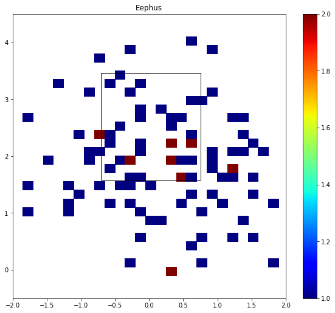

```python
left, width = 0.1, 0.65
bottom, height = 0.1, 0.65
bottom_h = left_h = left + width + 0.02

rect_scatter = [left, bottom, width, height]
#rect_histx = [left, bottom_h, width, 0.2]
#rect_histy = [left_h, bottom, 0.2, height]

plt.figure(1, figsize=(12, 10))

# start with a rectangular Figure


axScatter = plt.axes(rect_scatter)
#axHistx = plt.axes(rect_histx)
#axHisty = plt.axes(rect_histy)
bins_x = np.arange(-2, 0.1+2,0.15)
bins_y = np.arange(-1, 0.1+6, 0.15)
plt.hist2d(data = ep, x = 'px', y = 'pz', bins = [bins_x, bins_y], cmap = 'jet', cmin = 0.5);
axScatter.set_xlim((-2, 2))
axScatter.set_ylim((-0.5, 4.5))
someX = 0
someY = 3.4632659
axScatter.add_patch(Rectangle((someX - .7083 , someY - 1.8832 ), 1.467, 1.8832, color = 'black',fill=None, alpha=1))
plt.colorbar();
plt.title('Eephus');
```

These plots look really good, except for the eephus. We just don't have a lot of data for that. The other plots show some good trends for each pitch. I will definitely use these other plots later.

### Talk about some of the relationships you observed in this part of the investigation. How did the feature(s) of interest vary with other features in the dataset?

> Well the relationship between pfx_z/x and other variables didn't live up to they type. I like how my pitch types and pitch results (code and event) turned. I think those can be very polished plots. I also liked the violin plots when looking at the start and end speeds. I might turn those into box plots so they are a bit easier to understand. I really liked how the pitch location heat maps turned out. It actually can tell us a lot about how a pitcher uses his pitches.

### Did you observe any interesting relationships between the other features (not the main feature(s) of interest)?

> I really wasn't planning to split each pitch type into it own data frame, but it seems that is the best idea. Each pitch type has different influencing factors. I also wasn't expecting to create the pitch location heat maps. That idea came to me after looking at the movement correlations and not really finding anything. I think these are great.

## Multivariate Exploration

I'm going to look at the physical location of each pitch with a color variable which describes nasty. Nasty tops out at 100. In my own personal projects, I have done a lot with plotting this data like below. I'm using code which I came up with as a backbone for this visualizations. The rectangle is the estimated strike zone.

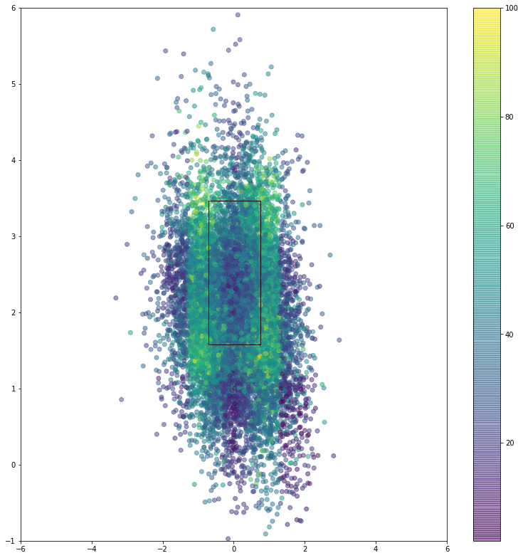

```python
nullfmt = NullFormatter()
left, width = 0.1, 0.65
bottom, height = 0.1, 0.65
bottom_h = left_h = left + width + 0.02

rect_scatter = [left, bottom, width, height]
#rect_histx = [left, bottom_h, width, 0.2]
#rect_histy = [left_h, bottom, 0.2, height]

# start with a rectangular Figure
plt.figure(1, figsize=(16, 16))

axScatter = plt.axes(rect_scatter)
#axHistx = plt.axes(rect_histx)
#axHisty = plt.axes(rect_histy)

# no labels
#axHistx.xaxis.set_major_formatter(nullfmt)
#axHisty.yaxis.set_major_formatter(nullfmt)

# the scatter plot:
sc = plt.scatter(df.px, df.pz, c = df.nasty, alpha = 0.5)

# now determine nice limits by hand:
#binwidth = 0.25
#xymax = max(np.max(np.abs(df.px)), np.max(np.abs(df.pz)))
#lim = (int(xymax/binwidth) + 1) * binwidth

axScatter.set_xlim((-6, 6))
axScatter.set_ylim((-1, 6))

#bins = np.arange(-lim, lim + binwidth, binwidth)
#axHistx.hist(df.px, bins=bins)
#axHisty.hist(df.pz, bins=bins, orientation='horizontal')

#axHistx.set_xlim(axScatter.get_xlim())
#axHisty.set_ylim(axScatter.get_ylim())

someX = 0
someY = 3.4632659
axScatter.add_patch(Rectangle((someX - .7083 , someY - 1.8832 ), 1.467, 1.8832, fill=None, alpha=1))
plt.colorbar(sc)
plt.show()
```

It looks like all of the pitches which are nastiest (green color) are located on the corners of the strike zone (the rectangle box). Let's look at all pitches which are nastier than 70. I'll look at pitch speed using size.

```python
df_nasty= df.query('nasty >= 70')
```

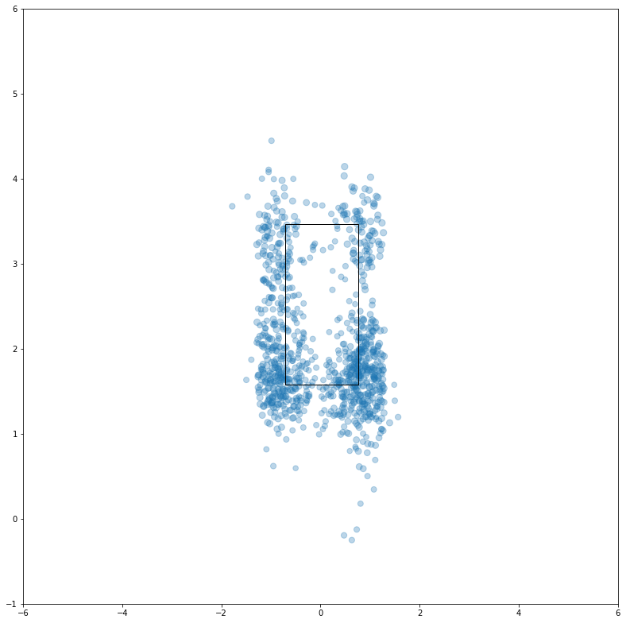

```python
nullfmt = NullFormatter()
left, width = 0.1, 0.65
bottom, height = 0.1, 0.65
bottom_h = left_h = left + width + 0.02

rect_scatter = [left, bottom, width, height]
#rect_histx = [left, bottom_h, width, 0.2]
#rect_histy = [left_h, bottom, 0.2, height]

# start with a rectangular Figure
plt.figure(1, figsize=(16, 16))

axScatter = plt.axes(rect_scatter)
#axHistx = plt.axes(rect_histx)
#axHisty = plt.axes(rect_histy)

# no labels
#axHistx.xaxis.set_major_formatter(nullfmt)
#axHisty.yaxis.set_major_formatter(nullfmt)

# the scatter plot:
sc = plt.scatter(df_nasty.px, df_nasty.pz,  s = df_nasty.start_speed - 25 , alpha = 0.3)

# now determine nice limits by hand:
#binwidth = 0.25
#xymax = max(np.max(np.abs(df.px)), np.max(np.abs(df.pz)))
#lim = (int(xymax/binwidth) + 1) * binwidth

axScatter.set_xlim((-6, 6))
axScatter.set_ylim((-1, 6))

#bins = np.arange(-lim, lim + binwidth, binwidth)
#axHistx.hist(df.px, bins=bins)
#axHisty.hist(df.pz, bins=bins, orientation='horizontal')

#axHistx.set_xlim(axScatter.get_xlim())
#axHisty.set_ylim(axScatter.get_ylim())

someX = 0
someY = 3.4632659
axScatter.add_patch(Rectangle((someX - .7083 , someY - 1.8832 ), 1.467, 1.8832, fill=None, alpha=1))
#plt.colorbar(sc)
plt.show()
```

The size doesn't do much for us. Since we know they are better than 70 nasty, we can use color to look at pitch speed.

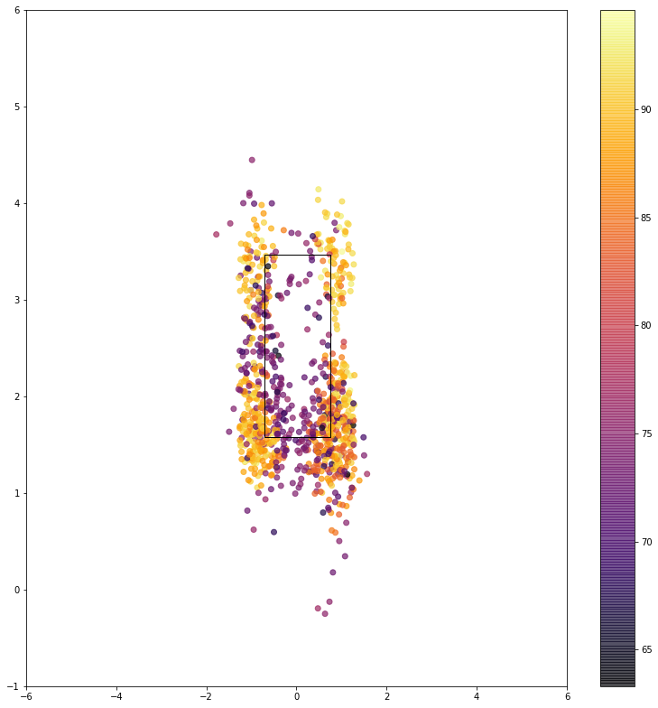

```python
nullfmt = NullFormatter()
left, width = 0.1, 0.65
bottom, height = 0.1, 0.65
bottom_h = left_h = left + width + 0.02

rect_scatter = [left, bottom, width, height]
#rect_histx = [left, bottom_h, width, 0.2]
#rect_histy = [left_h, bottom, 0.2, height]

# start with a rectangular Figure
plt.figure(1, figsize=(16, 16))

axScatter = plt.axes(rect_scatter)
#axHistx = plt.axes(rect_histx)
#axHisty = plt.axes(rect_histy)

# no labels
#axHistx.xaxis.set_major_formatter(nullfmt)
#axHisty.yaxis.set_major_formatter(nullfmt)

# the scatter plot:
sc = plt.scatter(df_nasty.px, df_nasty.pz,  c = df_nasty.start_speed, cmap = 'inferno' , alpha = 0.7)

# now determine nice limits by hand:
#binwidth = 0.25
#xymax = max(np.max(np.abs(df.px)), np.max(np.abs(df.pz)))
#lim = (int(xymax/binwidth) + 1) * binwidth

axScatter.set_xlim((-6, 6))
axScatter.set_ylim((-1, 6))

#bins = np.arange(-lim, lim + binwidth, binwidth)
#axHistx.hist(df.px, bins=bins)
#axHisty.hist(df.pz, bins=bins, orientation='horizontal')

#axHistx.set_xlim(axScatter.get_xlim())
#axHisty.set_ylim(axScatter.get_ylim())

someX = 0
someY = 3.4632659
axScatter.add_patch(Rectangle((someX - .7083 , someY - 1.8832 ), 1.467, 1.8832, fill=None, alpha=1))
plt.colorbar(sc)
plt.show()
```

I see that most pitches inside the strike zone are slower. These would be something like a churveball or eephus. We can actually see this in our next plot.

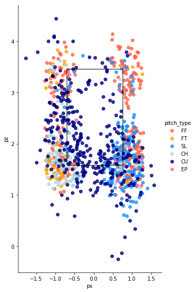

```python
color = ['tomato', 'orange','dodgerblue','lightblue','navy', 'hotpink']
g = sb.FacetGrid(data = df_nasty, hue = 'pitch_type', height = 8, aspect = 4/7, palette = color)
g = g.map(sb.regplot, 'px','pz', fit_reg = False)

someX = 0
someY = 3.4632659
g.axes[0, 0].add_patch(Rectangle((someX - .7083 , someY - 1.8832 ), 1.467, 1.8832, fill=None, color = 'black', alpha=1))
g.add_legend()
plt.show()
```

This visualization looks really good. It shows the pitch type and location. These pitches also have a nasty factor above 70. We can see the majority of these pitches are outside the strike zone. His curveball is one of the pitches which is nasty when in the strike zone. Greinke throws this pitch really well. I want to see what pitches have a nasty factor at 90 or above.

```python
df_nasty90= df.query('nasty >= 90')
```

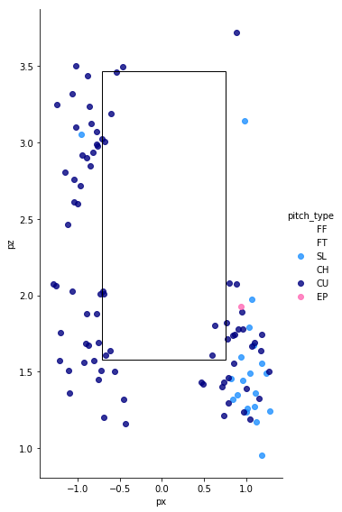

```python
color = ['tomato', 'orange','dodgerblue','lightblue','navy', 'hotpink']
g = sb.FacetGrid(data = df_nasty90, hue = 'pitch_type', height = 8, aspect = 4/7, palette = color)
g = g.map(sb.regplot, 'px','pz', fit_reg = False)

someX = 0
someY = 3.4632659
g.axes[0, 0].add_patch(Rectangle((someX - .7083 , someY - 1.8832 ), 1.467, 1.8832, fill=None, color = 'black', alpha=1))
g.add_legend()
plt.show()
```

This is interesting, his curveball continues to be the nastiest pitch he throws. His slider is also in this category of nasty.

### Talk about some of the relationships you observed in this part of the investigation. Were there features that strengthened each other in terms of looking at your feature(s) of interest?

> I was able to see the location of pitches which are considered nastiest. I also continued to see what pitch types were associated with these pitches.

### Were there any interesting or surprising interactions between features?

> I was surprised to see the curveball be the most common pitch which has a nasty factor of 90+.

```python
df.to_csv('finalInfo.csv')
```